# Workflow: Basics and Data Transformation

Module 02

Ray J. Hoobler

# Workflow Basics (Chapter 2, R for Data Science)

## Coding basics: Review R for Data Science, Chapter 2 (1/4)

You can use R to do basic math calculations:

```r
1 / 200 * 30
```

```
[1] 0.15
```

```r
(59 + 73 + 2) / 3
```

```
[1] 44.66667
```

```r
sin(pi / 2)
```

```
[1] 1
```

## Coding basics: Review R for Data Science, Chapter 2 (2/4)

### Create new objects with `<-`

```r
x <- 3 * 4
x
```

```
[1] 12
```

### Combine multiple elements into a vector with `c()`:

```r
primes <- c(2, 3, 5, 7, 11, 13)
primes
```

```
[1]  2  3  5  7 11 13
```

## Coding basics: Review R for Data Science, Chapter 2 (3/4)

### Basic arithmetic on vectors is applied to every element of of the vector:

```r
primes * 2
```

```
[1]  4  6 10 14 22 26
```

```r
primes - 1
```

```
[1]  1  2  4  6 10 12
```

## Coding basics: Review R for Data Science, Chapter 2 (4/4)

### Comments

R will ignore any text after # for that line.

```r
# create vector of primes
primes <- c(2, 3, 5, 7, 11, 13)

# multiply primes by 2
primes * 2
```

```
[1]  4  6 10 14 22 26
```

## What’s in a name?

````markdown
```{r}
i_use_snake_case
otherPeopleUseCamelCase
some.people.use.periods
And_aFew.People_RENOUNCEconvention
```
````

- snake case has few drawbacks
- camel case may be more easy to type; note the first word is typically lowercase
- periods may cause issues with some functions (not considered a best practice in Python)

## Calling functions

````markdown
```{r}
function_name(argument1 = value1, argument2 = value2, ...)
```
````

```r
seq(from = 1, to = 10, by = 2)
```

```
[1] 1 3 5 7 9
```

```r
seq(1, 10, 2)
```

```
[1] 1 3 5 7 9
```

## Module 2 Assignment 1

Complete the exercises in section [2.5 of R for Data Science](https://r4ds.hadley.nz/workflow-basics#exercises).

# Data Transformation (Chapter3, R for Data Science)

## Libraries Needed for the Following Slides

```r
library(tidyverse)
library(palmerpenguins)
```

## `dplyr` basics

`dplyr` functions have the following characteristics:

1. The first argument is a data frame.
2. The subsequent arguments describe what to do with the data frame.
3. The output is a new data frame.

Because the input and output are both data frames, you can string together multiple `dplyr` functions with the pipe operator `|>`.

**Note**

Previous versions of `dplyr` used the `%>%` operator which was imported from the `magrittr` package. The `|>` operator is now the preferred operator for piping in `dplyr` and is native to R.

## `dplyr` Functions for Transforming Rows (1/2)

- `filter()`
- `arrange()`
- `distinct()`

## `dplyr` Functions for Transforming Rows (2/2)

- `filter()` : Extracts rows that meet a logical condition.
- `arrange()` : Reorders rows.
- `distinct()` : Finds all unique rows, usually based on a subset of columns.

## `filter()`

Filter the `penguins` data frame to include only observations where the species is “Adelie”.

```r
penguins |> filter(species == "Adelie") |> tail()
```

| species | island | bill_length_mm | bill_depth_mm | flipper_length_mm | body_mass_g | sex | year |
| --- | --- | --- | --- | --- | --- | --- | --- |
| Adelie | Dream | 39.2 | 18.6 | 190 | 4250 | male | 2009 |
| Adelie | Dream | 36.6 | 18.4 | 184 | 3475 | female | 2009 |
| Adelie | Dream | 36.0 | 17.8 | 195 | 3450 | female | 2009 |
| Adelie | Dream | 37.8 | 18.1 | 193 | 3750 | male | 2009 |
| Adelie | Dream | 36.0 | 17.1 | 187 | 3700 | female | 2009 |
| Adelie | Dream | 41.5 | 18.5 | 201 | 4000 | male | 2009 |

We place the species name in quotes because it is a character string.

**Note**

Factors are used for categorical variables, variables that have a fixed and known set of possible values. They are also useful when you want to display character vectors in a non-alphabetical order.

## Use `filter()` to find outliers

Use `body_mass_g` variable of `penguins` data

### EDA Boxplot of `penguins` data

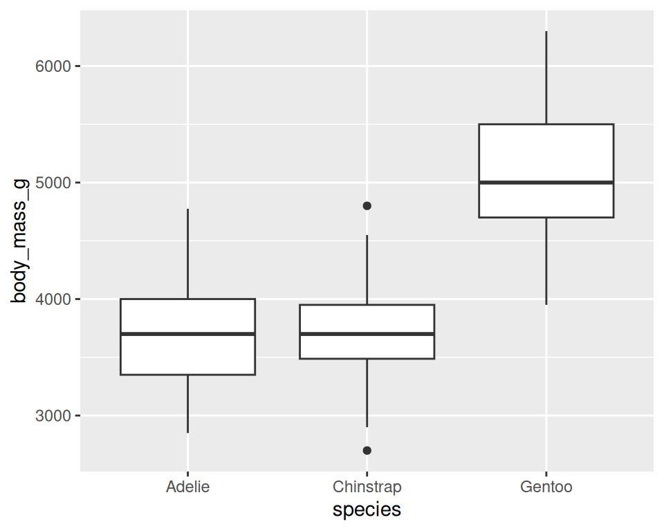

```r
penguins |> ggplot(aes(x = species, y = body_mass_g)) + geom_boxplot()
```

Based on the boxplot, only the *Chinstrap* species has outliers.

Outliers are observations have a value of 1.5 times the IQR. ($IQR = Q_3 - Q_1$)

$$\text{x}
\begin{cases}
\ge Q_3 + 1.5 \times IQR \\
\le Q_1 - 1.5 \times IQR
\end{cases}$$

## Find the Outliers and Apply the Filter (1/2)

```r
# Create a new data frame of the Chinstrap species
chinstrap <- penguins |> filter(species == "Chinstrap")

# Find the IQR, Q1 and Q3 values using stats functions
iqr_chinstrap <- IQR(chinstrap$body_mass_g, na.rm = TRUE)
q1_chinstrap <- quantile(chinstrap$body_mass_g, 0.25, na.rm = TRUE)[[1]]
q3_chinstrap <- quantile(chinstrap$body_mass_g, 0.75, na.rm = TRUE)[[1]]
```

```r
sprintf("IQR: %.2f", iqr_chinstrap)
```

```
[1] "IQR: 462.50"
```

```r
sprintf("Q1: %.2f", q1_chinstrap)
```

```
[1] "Q1: 3487.50"
```

```r
sprintf("Q3: %.2f", q3_chinstrap)
```

```
[1] "Q3: 3950.00"
```

Notice the `chinstrap$body_mass_g` variable is used in the `IQR()` and `quantile()` functions. This is a common way to access variables in a data frame. Notice the `na.rm = TRUE` argument in the functions. This argument removes missing values from the calculations.

These functions are not part of the `dplyr` package, but are part of the `stats` package which is loaded when R starts

I’m also using the `sprintf()` function to format the output. The `%.2f` argument tells R to format the output as a floating point number with two decimal places. Check out the `?sprintf` help file for more information on formatting output. We don’t often use this function with Markdown, but these types of functions are common in other languages like C and Python.

## Find the Outliers and Apply the Filter (2/2)

Outliers in the `penguins` data frame are observations where the `species` is “Chinstrap” and the `body_mass_g` is greater than or equal to 1.5 times the IQR or less than or equal to 1.5 times the IQR.  
This is $\ge$ 4.64kg and $\le$ 2.79kg, respectively.

```r
# Use IQR in filter function
penguins_outliers <- chinstrap |>
  filter(body_mass_g >= q3_chinstrap + 1.5 * iqr_chinstrap | body_mass_g <= q1_chinstrap - 1.5 * iqr_chinstrap
         )

penguins_outliers
```

| species | island | bill_length_mm | bill_depth_mm | flipper_length_mm | body_mass_g | sex | year |
| --- | --- | --- | --- | --- | --- | --- | --- |
| Chinstrap | Dream | 52.0 | 20.7 | 210 | 4800 | male | 2008 |
| Chinstrap | Dream | 46.9 | 16.6 | 192 | 2700 | female | 2008 |

## Using the `arrange()` function to reorder rows

```r
# Reorder the penguins_outliers data frame by body_mass_g
penguins_outliers |> arrange(body_mass_g)
```

| species | island | bill_length_mm | bill_depth_mm | flipper_length_mm | body_mass_g | sex | year |
| --- | --- | --- | --- | --- | --- | --- | --- |
| Chinstrap | Dream | 46.9 | 16.6 | 192 | 2700 | female | 2008 |
| Chinstrap | Dream | 52.0 | 20.7 | 210 | 4800 | male | 2008 |

```r
# Reorder the penguins_outliers data frame by body_mass_g in descending order
penguins_outliers |> arrange(desc(body_mass_g))
```

| species | island | bill_length_mm | bill_depth_mm | flipper_length_mm | body_mass_g | sex | year |
| --- | --- | --- | --- | --- | --- | --- | --- |
| Chinstrap | Dream | 52.0 | 20.7 | 210 | 4800 | male | 2008 |
| Chinstrap | Dream | 46.9 | 16.6 | 192 | 2700 | female | 2008 |

(Note: the original order was simply by order of appearance in the `penguins` data frame.)

## Using the `distinct()` function (1/2)

### To find unique rows in a data frame

```r
# Find unique rows in the penguins data frame
penguins |> distinct()
```

| species | island | bill_length_mm | bill_depth_mm | flipper_length_mm | body_mass_g | sex | year |
| --- | --- | --- | --- | --- | --- | --- | --- |
| Adelie | Torgersen | 39.1 | 18.7 | 181 | 3750 | male | 2007 |
| Adelie | Torgersen | 39.5 | 17.4 | 186 | 3800 | female | 2007 |
| Adelie | Torgersen | 40.3 | 18.0 | 195 | 3250 | female | 2007 |
| Adelie | Torgersen | NA | NA | NA | NA | NA | 2007 |
| Adelie | Torgersen | 36.7 | 19.3 | 193 | 3450 | female | 2007 |
| Adelie | Torgersen | 39.3 | 20.6 | 190 | 3650 | male | 2007 |
| Adelie | Torgersen | 38.9 | 17.8 | 181 | 3625 | female | 2007 |
| Adelie | Torgersen | 39.2 | 19.6 | 195 | 4675 | male | 2007 |
| Adelie | Torgersen | 34.1 | 18.1 | 193 | 3475 | NA | 2007 |
| Adelie | Torgersen | 42.0 | 20.2 | 190 | 4250 | NA | 2007 |

[output cut: 334 more lines]

```r
nrow(penguins)
```

```
[1] 344
```

## Using the `distinct()` function (2/2)

### Unique pairs of species and island

```r
penguins |> distinct(species, island)
```

| species | island |
| --- | --- |
| Adelie | Torgersen |
| Adelie | Biscoe |
| Adelie | Dream |
| Gentoo | Biscoe |
| Chinstrap | Dream |

## Module 2 Assignment 2

Answer question 4 in section [3.2.5 Exercises from R for Data Science (2e)](https://r4ds.hadley.nz/data-transform#exercises)

```r
library(nycflights13)

# Find the number of unique flights in the nycflights13 data frame
flights |> distinct(month, day) |> nrow()
```

```
[1] 365
```

## `dplyr` Functions for Transforming Columns (1/4)

### `mutate()`

Mutate may be the most powerful tool in the tidyverse.

We can use `mutate()` to create new columns or modify existing columns.

## Using `mutate()` to create a new column (1/3)

Simple mathematical transformation of an existing column: convert `body_mass_g` to kilograms.

```r
penguins_kg <- penguins |>
  mutate(body_mass_kg = body_mass_g / 1000, .before = body_mass_g)

penguins_kg
```

| species | island | bill_length_mm | bill_depth_mm | flipper_length_mm | body_mass_kg | body_mass_g | sex | year |
| --- | --- | --- | --- | --- | --- | --- | --- | --- |
| Adelie | Torgersen | 39.1 | 18.7 | 181 | 3.750 | 3750 | male | 2007 |
| Adelie | Torgersen | 39.5 | 17.4 | 186 | 3.800 | 3800 | female | 2007 |
| Adelie | Torgersen | 40.3 | 18.0 | 195 | 3.250 | 3250 | female | 2007 |
| Adelie | Torgersen | NA | NA | NA | NA | NA | NA | 2007 |
| Adelie | Torgersen | 36.7 | 19.3 | 193 | 3.450 | 3450 | female | 2007 |
| Adelie | Torgersen | 39.3 | 20.6 | 190 | 3.650 | 3650 | male | 2007 |
| Adelie | Torgersen | 38.9 | 17.8 | 181 | 3.625 | 3625 | female | 2007 |
| Adelie | Torgersen | 39.2 | 19.6 | 195 | 4.675 | 4675 | male | 2007 |
| Adelie | Torgersen | 34.1 | 18.1 | 193 | 3.475 | 3475 | NA | 2007 |
| Adelie | Torgersen | 42.0 | 20.2 | 190 | 4.250 | 4250 | NA | 2007 |

[output cut: 334 more lines]

## Using `mutate()` to create a new column (2/3)

We can use `mutate()` and use existing columns to create new columns.

```r
penguins_ratio <- penguins |>
  mutate(bill_ratio = bill_length_mm / bill_depth_mm, .before = bill_length_mm)

penguins_ratio
```

| species | island | bill_ratio | bill_length_mm | bill_depth_mm | flipper_length_mm | body_mass_g | sex | year |
| --- | --- | --- | --- | --- | --- | --- | --- | --- |
| Adelie | Torgersen | 2.090909 | 39.1 | 18.7 | 181 | 3750 | male | 2007 |
| Adelie | Torgersen | 2.270115 | 39.5 | 17.4 | 186 | 3800 | female | 2007 |
| Adelie | Torgersen | 2.238889 | 40.3 | 18.0 | 195 | 3250 | female | 2007 |
| Adelie | Torgersen | NA | NA | NA | NA | NA | NA | 2007 |
| Adelie | Torgersen | 1.901554 | 36.7 | 19.3 | 193 | 3450 | female | 2007 |
| Adelie | Torgersen | 1.907767 | 39.3 | 20.6 | 190 | 3650 | male | 2007 |
| Adelie | Torgersen | 2.185393 | 38.9 | 17.8 | 181 | 3625 | female | 2007 |
| Adelie | Torgersen | 2.000000 | 39.2 | 19.6 | 195 | 4675 | male | 2007 |
| Adelie | Torgersen | 1.883978 | 34.1 | 18.1 | 193 | 3475 | NA | 2007 |
| Adelie | Torgersen | 2.079208 | 42.0 | 20.2 | 190 | 4250 | NA | 2007 |

[output cut: 334 more lines]

## Using `mutate()` to create a new column (3/3)

We can apply logical conditions to create new columns.

```r
penguins_binary <- penguins |>
  mutate(island_binary = if_else(island == "Dream", 1, 0), .before = island)

penguins_binary
```

| species | island_binary | island | bill_length_mm | bill_depth_mm | flipper_length_mm | body_mass_g | sex | year |
| --- | --- | --- | --- | --- | --- | --- | --- | --- |
| Adelie | 0 | Torgersen | 39.1 | 18.7 | 181 | 3750 | male | 2007 |
| Adelie | 0 | Torgersen | 39.5 | 17.4 | 186 | 3800 | female | 2007 |
| Adelie | 0 | Torgersen | 40.3 | 18.0 | 195 | 3250 | female | 2007 |
| Adelie | 0 | Torgersen | NA | NA | NA | NA | NA | 2007 |
| Adelie | 0 | Torgersen | 36.7 | 19.3 | 193 | 3450 | female | 2007 |
| Adelie | 0 | Torgersen | 39.3 | 20.6 | 190 | 3650 | male | 2007 |
| Adelie | 0 | Torgersen | 38.9 | 17.8 | 181 | 3625 | female | 2007 |
| Adelie | 0 | Torgersen | 39.2 | 19.6 | 195 | 4675 | male | 2007 |
| Adelie | 0 | Torgersen | 34.1 | 18.1 | 193 | 3475 | NA | 2007 |
| Adelie | 0 | Torgersen | 42.0 | 20.2 | 190 | 4250 | NA | 2007 |

[output cut: 334 more lines]

## Keep `mutate()` in mind when you ask the question. . .

Do I need to change something in my data frame?

## Using `select()` to keep or drop columns (1/4)

Probably the most straightforward function in `dplyr`.

Simply list the columns you want to keep, or…

```r
penguins_select <- penguins |>
  select(species, island, body_mass_g, sex, year)

penguins_select
```

| species | island | body_mass_g | sex | year |
| --- | --- | --- | --- | --- |
| Adelie | Torgersen | 3750 | male | 2007 |
| Adelie | Torgersen | 3800 | female | 2007 |
| Adelie | Torgersen | 3250 | female | 2007 |
| Adelie | Torgersen | NA | NA | 2007 |
| Adelie | Torgersen | 3450 | female | 2007 |
| Adelie | Torgersen | 3650 | male | 2007 |
| Adelie | Torgersen | 3625 | female | 2007 |
| Adelie | Torgersen | 4675 | male | 2007 |
| Adelie | Torgersen | 3475 | NA | 2007 |
| Adelie | Torgersen | 4250 | NA | 2007 |

[output cut: 334 more lines]

## Using `select()` to keep or drop columns (2/4)

…list the columns you want to drop.

```r
penguins_drop <- penguins |>
  select(-bill_length_mm, -bill_depth_mm, -flipper_length_mm)

penguins_drop
```

| species | island | body_mass_g | sex | year |
| --- | --- | --- | --- | --- |
| Adelie | Torgersen | 3750 | male | 2007 |
| Adelie | Torgersen | 3800 | female | 2007 |
| Adelie | Torgersen | 3250 | female | 2007 |
| Adelie | Torgersen | NA | NA | 2007 |
| Adelie | Torgersen | 3450 | female | 2007 |
| Adelie | Torgersen | 3650 | male | 2007 |
| Adelie | Torgersen | 3625 | female | 2007 |
| Adelie | Torgersen | 4675 | male | 2007 |
| Adelie | Torgersen | 3475 | NA | 2007 |
| Adelie | Torgersen | 4250 | NA | 2007 |

[output cut: 334 more lines]

## Using `select()` to keep or drop columns (3/4)

You can also use the index of the column and use the `:` operator to select a range of columns.

```r
penguins_select_index <- penguins |>
  select(1:2, 6:8)

# or use the ! (not) operator to drop columns

penguins_select_index2 <- penguins |>
  select(!3:5)

penguins_select_index
```

| species | island | body_mass_g | sex | year |
| --- | --- | --- | --- | --- |
| Adelie | Torgersen | 3750 | male | 2007 |
| Adelie | Torgersen | 3800 | female | 2007 |
| Adelie | Torgersen | 3250 | female | 2007 |
| Adelie | Torgersen | NA | NA | 2007 |
| Adelie | Torgersen | 3450 | female | 2007 |
| Adelie | Torgersen | 3650 | male | 2007 |
| Adelie | Torgersen | 3625 | female | 2007 |
| Adelie | Torgersen | 4675 | male | 2007 |
| Adelie | Torgersen | 3475 | NA | 2007 |
| Adelie | Torgersen | 4250 | NA | 2007 |

[output cut: 334 more lines]

```r
penguins_select_index2
```

| species | island | body_mass_g | sex | year |
| --- | --- | --- | --- | --- |
| Adelie | Torgersen | 3750 | male | 2007 |
| Adelie | Torgersen | 3800 | female | 2007 |
| Adelie | Torgersen | 3250 | female | 2007 |
| Adelie | Torgersen | NA | NA | 2007 |
| Adelie | Torgersen | 3450 | female | 2007 |
| Adelie | Torgersen | 3650 | male | 2007 |
| Adelie | Torgersen | 3625 | female | 2007 |
| Adelie | Torgersen | 4675 | male | 2007 |
| Adelie | Torgersen | 3475 | NA | 2007 |
| Adelie | Torgersen | 4250 | NA | 2007 |

[output cut: 334 more lines]

## Using `select()` to keep or drop columns (4/4)

See ?select for more details. Once you know regular expressions (the topic of Chapter 15) you’ll also be able to use matches() to select variables that match a pattern.

You can rename variables as you select() them by using =. The new name appears on the left hand side of the =, and the old variable appears on the right hand side:

```r
penguins_rename <- penguins |>
  select(Species = species, Island = island, "Body Mass (g)" = body_mass_g)

penguins_rename2 <- penguins |>
  rename(Species = species, Island = island, "Body Mass (g)" = body_mass_g)

penguins_rename
```

| Species | Island | Body Mass (g) |
| --- | --- | --- |
| Adelie | Torgersen | 3750 |
| Adelie | Torgersen | 3800 |
| Adelie | Torgersen | 3250 |
| Adelie | Torgersen | NA |
| Adelie | Torgersen | 3450 |
| Adelie | Torgersen | 3650 |
| Adelie | Torgersen | 3625 |
| Adelie | Torgersen | 4675 |
| Adelie | Torgersen | 3475 |
| Adelie | Torgersen | 4250 |

[output cut: 334 more lines]

```r
penguins_rename2
```

| Species | Island | bill_length_mm | bill_depth_mm | flipper_length_mm | Body Mass (g) | sex | year |
| --- | --- | --- | --- | --- | --- | --- | --- |
| Adelie | Torgersen | 39.1 | 18.7 | 181 | 3750 | male | 2007 |
| Adelie | Torgersen | 39.5 | 17.4 | 186 | 3800 | female | 2007 |
| Adelie | Torgersen | 40.3 | 18.0 | 195 | 3250 | female | 2007 |
| Adelie | Torgersen | NA | NA | NA | NA | NA | 2007 |
| Adelie | Torgersen | 36.7 | 19.3 | 193 | 3450 | female | 2007 |
| Adelie | Torgersen | 39.3 | 20.6 | 190 | 3650 | male | 2007 |
| Adelie | Torgersen | 38.9 | 17.8 | 181 | 3625 | female | 2007 |
| Adelie | Torgersen | 39.2 | 19.6 | 195 | 4675 | male | 2007 |
| Adelie | Torgersen | 34.1 | 18.1 | 193 | 3475 | NA | 2007 |
| Adelie | Torgersen | 42.0 | 20.2 | 190 | 4250 | NA | 2007 |

[output cut: 334 more lines]

## Using `relocate()` to move columns

`relocate()` is used to move columns to a new position in the data frame.

By default, variables are moved to the first position; however, the `.after` or `.before` arguments can be used to specify a new position.

```r
penguins_relocate <- penguins |>
  relocate(body_mass_g, .after = island)

penguins_relocate
```

| species | island | body_mass_g | bill_length_mm | bill_depth_mm | flipper_length_mm | sex | year |
| --- | --- | --- | --- | --- | --- | --- | --- |
| Adelie | Torgersen | 3750 | 39.1 | 18.7 | 181 | male | 2007 |
| Adelie | Torgersen | 3800 | 39.5 | 17.4 | 186 | female | 2007 |
| Adelie | Torgersen | 3250 | 40.3 | 18.0 | 195 | female | 2007 |
| Adelie | Torgersen | NA | NA | NA | NA | NA | 2007 |
| Adelie | Torgersen | 3450 | 36.7 | 19.3 | 193 | female | 2007 |
| Adelie | Torgersen | 3650 | 39.3 | 20.6 | 190 | male | 2007 |
| Adelie | Torgersen | 3625 | 38.9 | 17.8 | 181 | female | 2007 |
| Adelie | Torgersen | 4675 | 39.2 | 19.6 | 195 | male | 2007 |
| Adelie | Torgersen | 3475 | 34.1 | 18.1 | 193 | NA | 2007 |
| Adelie | Torgersen | 4250 | 42.0 | 20.2 | 190 | NA | 2007 |

[output cut: 334 more lines]

## The pipe operator `|>`

We can string together multiple `dplyr` functions with the pipe operator `|>`.

Let’s find the five largest penguins by body mass, convert the mass to kg, and create a table showing the species, island, and body mass. Finally, we can rename the variables to make the table more readable.

```r
penguins |>
  mutate(body_mass_kg = body_mass_g / 1000) |>
  arrange(desc(body_mass_kg)) |>
  select(species, island, body_mass_kg) |>
  rename(Species = species, Island = island, "Body Mass (kg)" = body_mass_kg) |>
  head(5)
```

| Species | Island | Body Mass (kg) |
| --- | --- | --- |
| Gentoo | Biscoe | 6.30 |
| Gentoo | Biscoe | 6.05 |
| Gentoo | Biscoe | 6.00 |
| Gentoo | Biscoe | 6.00 |
| Gentoo | Biscoe | 5.95 |

For exploratory data analysis, we may not save the table as a new object.

## `group_by()` and `summarize()`

- `group_by()` : Group data by one or more variables.
- `summarize()` : Summarize data by collapsing each group into a single row.

## Using `group_by()`

Group the `penguins` data frame by `species` and `island`.

Look carefully at the new data frame. What’s changed?

```r
penguins_grouped <- penguins |>
  group_by(species, island)

penguins_grouped
```

| species | island | bill_length_mm | bill_depth_mm | flipper_length_mm | body_mass_g | sex | year |
| --- | --- | --- | --- | --- | --- | --- | --- |
| Adelie | Torgersen | 39.1 | 18.7 | 181 | 3750 | male | 2007 |
| Adelie | Torgersen | 39.5 | 17.4 | 186 | 3800 | female | 2007 |
| Adelie | Torgersen | 40.3 | 18.0 | 195 | 3250 | female | 2007 |
| Adelie | Torgersen | NA | NA | NA | NA | NA | 2007 |
| Adelie | Torgersen | 36.7 | 19.3 | 193 | 3450 | female | 2007 |
| Adelie | Torgersen | 39.3 | 20.6 | 190 | 3650 | male | 2007 |
| Adelie | Torgersen | 38.9 | 17.8 | 181 | 3625 | female | 2007 |
| Adelie | Torgersen | 39.2 | 19.6 | 195 | 4675 | male | 2007 |
| Adelie | Torgersen | 34.1 | 18.1 | 193 | 3475 | NA | 2007 |
| Adelie | Torgersen | 42.0 | 20.2 | 190 | 4250 | NA | 2007 |

[output cut: 334 more lines]

The data frame has a new class attribute: “Groups”

## Using `summarize()` on grouped data

Summarize the grouped data frame by calculating the mean `body_mass_g` for each

```r
#| code-fold: show

penguins_grouped |>
  summarize(mean_body_mass_g = mean(body_mass_g, na.rm = TRUE))
```

| species | island | mean_body_mass_g |
| --- | --- | --- |
| Adelie | Biscoe | 3709.659 |
| Adelie | Dream | 3688.393 |
| Adelie | Torgersen | 3706.373 |
| Chinstrap | Dream | 3733.088 |
| Gentoo | Biscoe | 5076.016 |

## Using `group_by()` and `summarize()` together

```r
penguins_grouped_mean <- penguins |>
  group_by(species) |>
  summarize(
    count = n(),
    mean_body_mass_g = mean(body_mass_g, na.rm = TRUE)
    ) |>
  ungroup()

penguins_grouped_mean
```

| species | count | mean_body_mass_g |
| --- | --- | --- |
| Adelie | 152 | 3700.662 |
| Chinstrap | 68 | 3733.088 |
| Gentoo | 124 | 5076.016 |

## Module 2 Assignment 3

Ask a question about the `penguins` data frame and use `dplyr` functions to answer it.

Use the final output of your analysis to create a table and ggplot2 visualization. For your visualization, include a title, subtitle, axis labels, and a caption.

```r
# Question: What is the average body mass of penguins by Species and Island?
penguins_analysis <- penguins |>
  group_by(species, island) |>
  summarize(
    count = n(),
    mean_body_mass_g = mean(body_mass_g, na.rm = TRUE)
    ) |>
  ungroup() |>
  rename(Species = species, Island = island, Count = count, "Mean Body Mass (g)" = mean_body_mass_g)

penguins_analysis
```

| Species | Island | Count | Mean Body Mass (g) |
| --- | --- | --- | --- |
| Adelie | Biscoe | 44 | 3709.659 |
| Adelie | Dream | 56 | 3688.393 |
| Adelie | Torgersen | 52 | 3706.373 |
| Chinstrap | Dream | 68 | 3733.088 |
| Gentoo | Biscoe | 124 | 5076.016 |

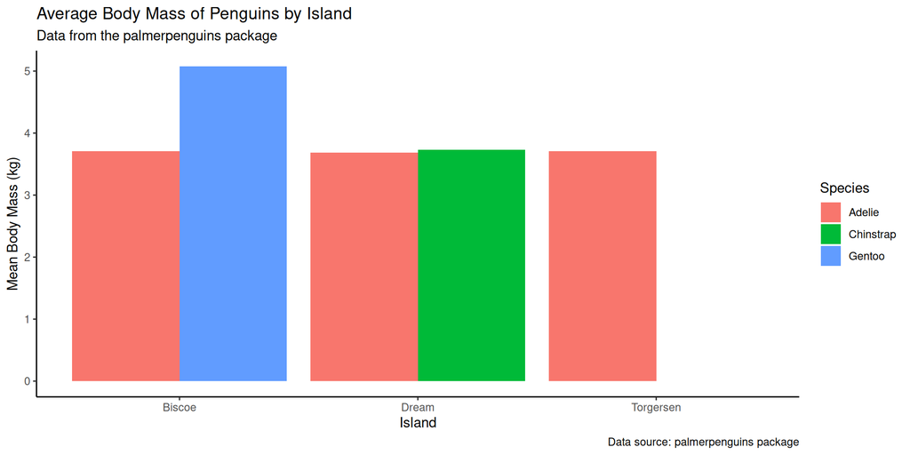

```r
penguins_analysis |>
  ggplot(aes(x = Island, y = `Mean Body Mass (g)`/1000, fill = Species)) +
  geom_col(position = position_dodge(preserve = "single")) +
  labs(title = "Average Body Mass of Penguins by Island",
       subtitle = "Data from the palmerpenguins package",
       x = "Island",
       y = "Mean Body Mass (kg)",
       caption = "Data source: palmerpenguins package") +
  theme_classic()
```

# End of Module 2